# Lecture 16 - Intro to Probability, pt. II

October 26, 2023

## Today

1. Conditional probabilities
2. Homework review
3. Probability distributions

## Conditional probabilities

- a *conditional probability* is the probability of one outcome *conditional* on another
- written as p(A | B), read as “probability of A *given* B”
- probability of the intersection of A and B, divided by the probability of B

## Conditional probabilities

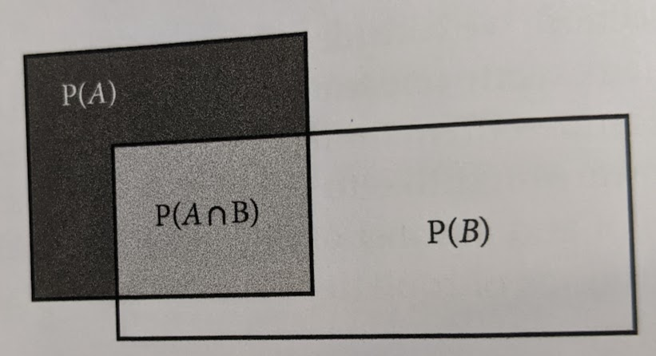

\(\Huge p(A|B) = \frac{p(A ~ \cap ~ B)}{p(B)}\)

## Conditional probabilities

|  | plain | sparkly | total |
| --- | --- | --- | --- |
| black hair | 49 | 12 | 61 |
| brown hair | 32 | 7 | 39 |
| total | 81 | 19 | 100 |

- probability of sparkly shoes **IF** you have black hair?

## Conditional probabilities

|  | plain | sparkly | total |
| --- | --- | --- | --- |
| black hair | 49 | 12 | 61 |
| brown hair | 32 | 7 | 39 |
| total | 81 | 19 | 100 |

- probability of sparkly shoes **IF** you have black hair?  
p(A | B) = p(A \(\cap\) B)/p(B) =

## Conditional probabilities

|  | plain | sparkly | total |
| --- | --- | --- | --- |
| black hair | 49 | 12 | 61 |
| brown hair | 32 | 7 | 39 |
| total | 81 | 19 | 100 |

- probability of sparkly shoes **IF** you have black hair?  
p(A | B) = p(A \(\cap\) B)/p(B) = 12 / 61 = 0.197

## Conditional probabilities

- recall that if A and B are independent, p( A \(\cap\) B) = p(A) * p(B)
- so if A and B are independent:

\(\Large \begin{aligned} p(A \mid B) &= \frac{p(A ~ \cap ~ B)}{p(B)} \\ \\ &= \frac{p(A)p(B)}{p(B)} = p(A) \end{aligned}\)

## Conditional probabilities

|  | plain | sparkly | total |
| --- | --- | --- | --- |
| black hair | 49 | 12 | 61 |
| brown hair | 32 | 7 | 39 |
| total | 81 | 19 | 100 |

Does a kid’s hair color affect the probability that their parents will get them a sweet pair of sparkly shoes?

p(sparkle shoes | black hair) = 0.197

p(sparkle shoes) = 0.19

## Rules of probability: recap

1. The probability of an *outcome* is the number of times the outcome occurs divided by the total number of trials.
2. The probability of a *complex event* is the sum of the probabilities of its constitutive events.
3. The probability of a *shared event* is the product of the probabilities of its constitutive events, so long as they’re independent.
4. The sum of the probabilities of *all possible outcomes* of an event is equal to 1.
5. A *conditional probability* is probability of one outcome *conditional* on another, and is equal to the probability of the intersection of the outcomes, divided by the probability of the condition

## Today

1. Conditional probabilities
2. Homework review
3. Probability distributions

## Homework Review - birthday twinsies

**The Birthday Problem** is a classic problem in probability:

how many people must be in a room for there to be > 50% probability that *at least* two of them share a birthday?

## Homework Review - birthday twinsies

Write a function for simulating the birthday problem. The argument of the function should be the number of people in the room, and it should return the probability (from simulations), that two or more share a birthday.

When in doubt, start w/ the pseudocode

## Homework Review - birthday twinsies

## Homework Review - birthday twinsies

```r
# Write a function with argument N (number of people)

    # draw N birthdays from the year (w/ replacement!)

    # if there are birthday duplicates
    #   log as a "bday twinsies" event

# Run this function for each simulation
#   return the proportion of simulations with birthday twinsies
```

## My solution

```r
# Write a function where you
birthdaySharing <- function(myN){
  # draw N birthdays from the year (w/ replacement!)
  birthdays = sample(1:365, myN, replace=T)
    # if there are birthday duplicates
  if (sum(duplicated(birthdays))>0) {
            #   log as a "bday twinsies" event
    myOut = TRUE} else {myOut = FALSE}
  return(myOut)
}

birthdaySim <- function(myP){
# Run the function for each simulation for a given P
myOut = sapply(1:1e5,function(x){birthdaySharing(myP)})
#   return the proportion of simulations with birthday twinsies
  return(sum(myOut)/1e5)}

birthdaySims <- sapply(1:30,function(n){birthdaySim(n)})
```

## Another solution

```r
sim.bday <- function(N){
    prop.twinsies <- sum(
                    replicate(1e5,
                        length(
                            unique(
                                sample(1:365,N,replace=TRUE)
                            )
                        ) < N)
                   )/1e5
    return(prop.twinsies)
}
```

## My solution

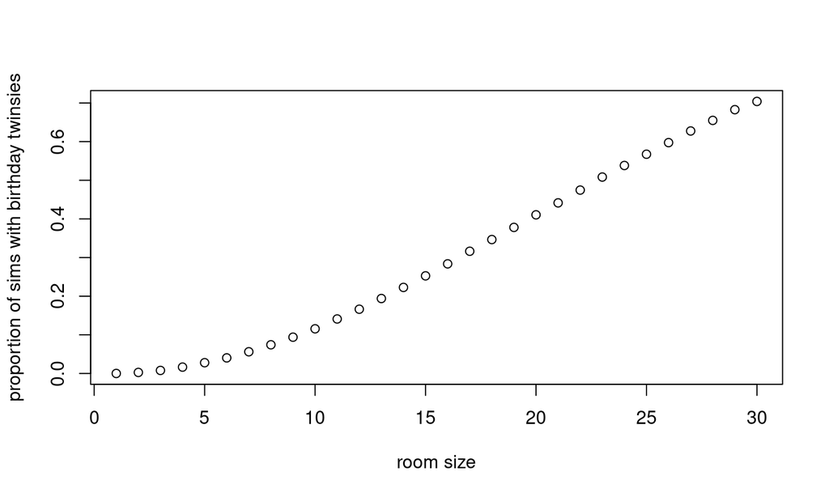

```r
plot(birthdaySims, xlab="room size",
     ylab = "proportion of sims with birthday twinsies")
```

## My solution

```r
which(birthdaySims > 0.5)[1]
```

```
## [1] 23
```

## Birthday problem - analytical solution

A = two people share a birthday  
A’ = no people share a birthday  
N = number of people in the room

For N=2, what is p(A’)?

\(\large \begin{aligned} p(A') &= \frac{365}{365} \times \frac{364}{365} \\ \end{aligned}\)

For N=3, what is p(A’)?

\(\large \begin{aligned} p(A') &= \frac{365}{365} \times \frac{364}{365} \times \frac{363}{365} \\ \end{aligned}\)

## Birthday problem - analytical solution

A = two people share a birthday  
A’ = no people share a birthday  
N = number of people in the room

For any value of N:

\(\large \begin{aligned} p(A') &= \frac{365}{365} \times \frac{364}{365} \times \ldots \times \frac{365-(N-1)}{365}\\ \end{aligned}\)

## Today

1. Conditional probabilities
2. Homework review
3. Probability distributions

## Coin-flipping

Let’s say I hand you a quarter and ask you to flip it 3 times and count the number of heads that you get.

- This is the **state space** (the list of all possible outcomes)
  - {HHH, HHT, HTH, THH, TTH, THT, HTT, TTT}
- Some questions to answer in your teams:
1. What is the probability of the sequence THH?
2. What is the probability I get exactly 2 heads out of 3 flips?
3. What is the probabilty I *do not* get exactly 2 heads out of 3 flips?

## Coin-flipping: 3-flip state space

- First, let’s define the **state space** (the list of all possible outcomes)
  - {HHH, HHT, HTH, THH, TTH, THT, HTT, TTT}
1. What is the probability of the sequence THH?
   - {HHH, HHT, HTH, THH, TTH, THT, HTT, TTT} = 1/8
2. What is the probability I get exactly 2 heads out of 3 flips?
   - {HHH, HHT, HTH, THH, TTH, THT, HTT, TTT} = 3/8
3. What is the probabilty I *do not* get exactly 2 heads out of 3 flips?
   - { HHH, HHT, HTH, THH, TTH, THT, HTT, TTT} = 1 - 3/8 = 5/8

## Coin-flipping: 4-flip state space

What about if I gave you 4 flips? What’s p(2 heads)?

HHHH, THHT, HHTH, TTHH, HTTH, TTHT, HHTT, TTTT,  
THHH, HHHT, THTH, HTHH, TTTH, HTHT, THTT, HTTT

p(2 heads) = 6/16 = 3/8  
Clearly, writing out all possible outcomes and colorizing them using CSS notation in Rmarkdown and then counting them will get tedious.

We must generalize!

## Coin-flipping: 4-flip state space

state space =

HHHH, THHT, HHTH, TTHH, HTTH, TTHT, HHTT, TTTT,  
THHH, HHHT, THTH, HTHH, TTTH, HTHT, THTT, HTTT

| Heads | Probability |
| --- | --- |
| 0 | 1/16 |
| 1 | 4/16 |
| 2 | 6/16 |
| 3 | 4/16 |
| 4 | 1/16 |

## Coin-flipping: 4-flip state space

state space =

HHHH, THHT, HHTH, TTHH, HTTH, TTHT, HHTT, TTTT,  
THHH, HHHT, THTH, HTHH, TTTH, HTHT, THTT, HTTT

This is a distribution of probabilities…

Can we make a **probability distribution**?

## Probability distributions, random variables

A *probability distribution* is a function that provides the probability of each outcome in the sample space.

In doing so, it is implicitly treating the outcome of the process (in this case, coin-flipping) as a *random variable*.

A *random variable* is a variable whose value is the outcome of a *stochastic* (or random) *process*.

## Coin-flipping: a probability distribution

| Heads | Probability |
| --- | --- |
| 0 | 1/16 |
| 1 | 4/16 |
| 2 | 6/16 |
| 3 | 4/16 |
| 4 | 1/16 |

\(\ p(\text{1 head}) < p(\text{2 heads})\)

## Coin-flipping: a probability distribution

\(\ p(\text{1 head}) < p(\text{2 heads})\)

but we know, out of 4 flips:

\(\ p(\text{HTTT}) = p(\text{HTHT})\)

so what’s the deal?

## Coin-flipping: a probability distribution

\(p(\text{1 head in 4 flips})\)

HHHH, THHT, HHTH, TTHH, HTTH, TTHT, HHTT, TTTT,  
THHH, HHHT, THTH, HTHH, TTTH, HTHT, THTT, HTTT

{ HTTT, THTT, TTHT, TTTH } = 4/16

## Coin-flipping: a probability distribution

\(p(\text{2 heads in 4 flips})\)

HHHH, THHT, HHTH, TTHH, HTTH, TTHT, HHTT, TTTT,  
THHH, HHHT, THTH, HTHH, TTTH, HTHT, THTT, HTTT

{ HHTT, HTHT, HTTH, THHT THTH TTHH } = 6/16

Because the coin is fair, each **shared event** (comprised of 4 simple events) is equi-probable.

But, there are more *ways* of realizing the complex event of **(2heads)**!

## Coin-flipping: a probability distribution

So, we know that our *probability distribution function* will have two components:

1. The probability of each **shared event**
2. The number of shared events that give a desired outcome (**complex event**)

Let’s generalize for more flips!

*n* = number of trials  
*k* = number of successes  
*p* = probability of heads (assume 1/2)

## Coin-flipping: a probability distribution

*n* = number of flips  
*k* = number of heads  
*p* = probability of heads (assume 1/2)

Two components to calculating the probability of *k* successes:

Part 1: what’s the probability of the **shared event** comprised of a specific sequence of heads and tails??

\(\Large (1/2)^{n}\)

Part 2: how many permutations of *n* events give *k* heads?

## Coin-flipping: a probability distribution

### how many permutations of *n* events give *k* successes?

For four flips, we had the table below:

| Heads | Probability |
| --- | --- |
| 0 | 1/16 |
| 1 | 4/16 |
| 2 | 6/16 |
| 3 | 4/16 |
| 4 | 1/16 |

## Coin-flipping: a probability distribution

We can calculate for specific values of *n* and *k*:

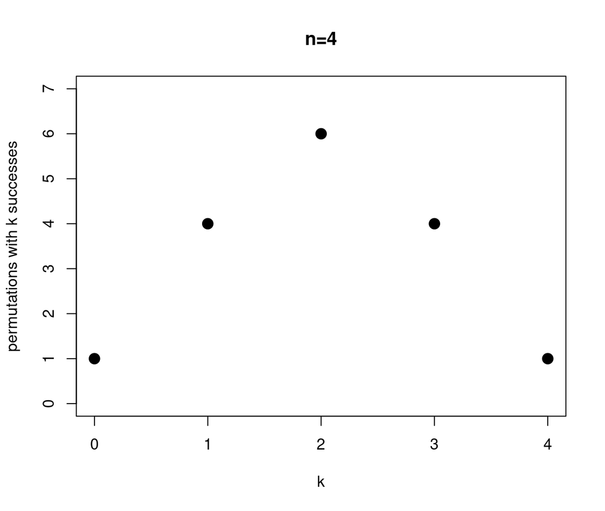

## Coin-flipping: a probability distribution

We can calculate for specific values of *n* and *k*:

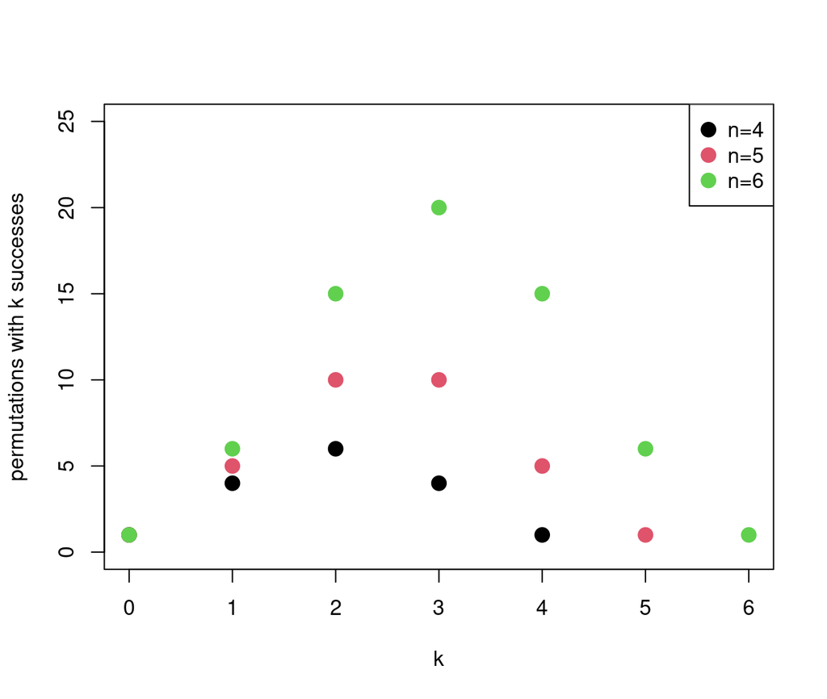

## Coin-flipping: a probability distribution

We can calculate for specific values of *n* and *k*:

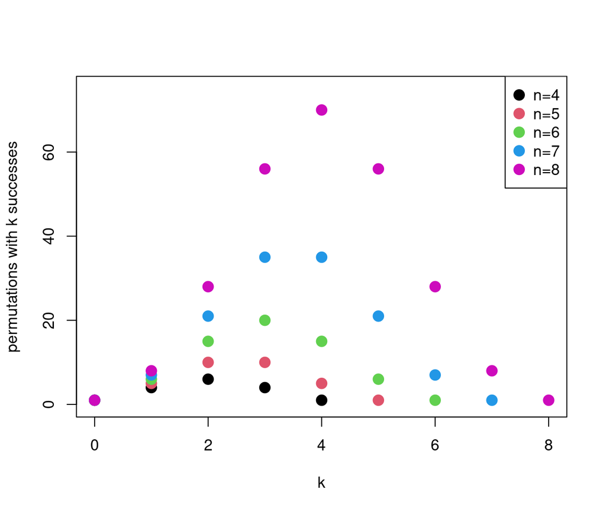

## Coin-flipping: a probability distribution

### how many permutations of *n* events give *k* successes?

Pascal’s Triangle!

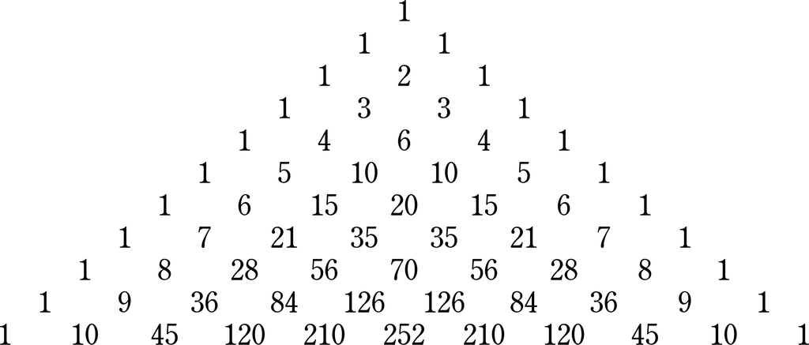

## Coin-flipping: a probability distribution

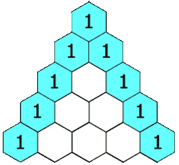

## Not just Pascal’s triangle

Khayyam’s triangle (Persia, 1100s)

Yang Hui’s triangle (China, 1200s)

Tartaglia’s triangle (Italy, 1500s)

Pascal’s triangle (France, 1600s)

## Yang Hui’s triangle

[figure not shown]

## Coin-flipping: a probability distribution

### how many permutations of *n* events give *k* successes?

Binomial coefficient!

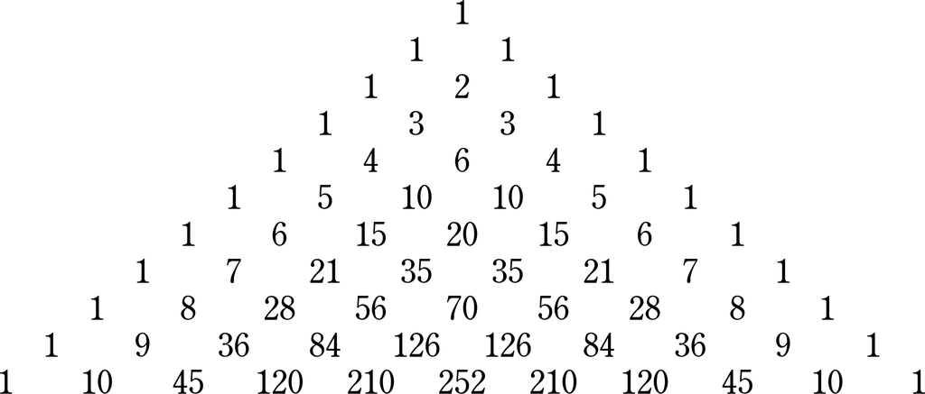

## Coin-flipping: a probability distribution

### how many permutations of *n* events give *k* successes?

\(\Huge {{n}\choose{k}} = \frac{n!}{k!(n-k)!}\)

\(\large x! = x \times (x-1) \times (x-2) \times \dots \times 1\)

## Coin-flipping: a probability distribution

*n* = number of flips  
*k* = number of heads *p* = probability of heads (assume 1/2)

Two components to calculating the probability of *k* successes:

Part 1: what’s the probability of each **shared event**

\(\Large (1/2)^{n}\)

Part 2: how many permutations give *k* successes?

\(\Large {{n}\choose{k}} = \frac{n!}{k!(n-k)!}\)

## Coin-flipping: probability distribution function

*n* trials, *k* successes, 1/2 probability of success

\(\ {{n}\choose{k}}(1/2)^{n}\)

Work in groups to write a function that returns the probability of a number of heads (*k*) given a probability of flipping heads of 1/2 and a number of flips (*n*).

Hint - check out the function `choose()`

Make a plot with 1 to 100 on the x axis, and the y axis shows your probability of x heads if you flip a coin 100 times.

## Coin-flipping: probability distribution function

*n* trials, *k* successes, 1/2 probability of success

\(\ {{n}\choose{k}}(1/2)^{n}\)

```r
    coin.flip.prob <- function(n,k){
        prob <- choose(n,k) * (1/2)^n
        return(prob)
    }
```

## Coin-flipping: probability distribution function

```r
    par(oma=c(3,0,0,0))
    plot(coin.flip.prob(n=100,k=0:100),
            xlab="heads",ylab="probability",
            pch=20,col=adjustcolor(1,0.7))
```

## Coin-flipping: probability distribution function

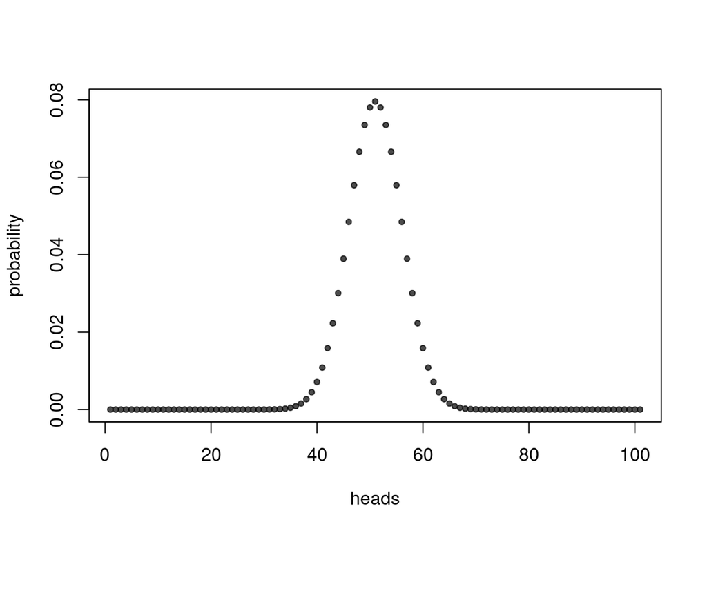

## Coin-flipping: probability distribution function

What if we change p?

If p(heads) = 0.1 and you flip a coin 3 times,

p(HHH) = ?  
p(TTT) = ?  
p(THH) = ?

## Coin-flipping: probability distribution function

If p(heads) = 0.1 and you flip a coin 3 times,

p(HHH) = \((0.1)^{3}\) = 0.001  
p(TTT) = \((0.9)^{3}\) =0.729  
p(THH) = \((0.9)^{1} \times (0.1)^{2}\) = 0.009

## Generalizing for different values of p

*n* = number of trials  
*k* = number of successes  
*p* = probability of success (for coin flips, assume 1/2)

Two components to calculating the probability of *k* successes:

Part 1: what’s the probability of the **shared event** comprised of *k* successes and *n*-*k* failures?

\(\Large p^k \times (1-p)^{n-k}\)

Part 2:

\(\ {{n}\choose{k}}\)

## The binomial distribution!!!

\(\Large {{n}\choose{k}} p^k \times (1-p)^{n-k}\)

## Write a function!

Work in your teams to edit your function from before to account for variable values of p.

## Write a function

```r
    coin.flip.prob <- function(n,k,p){
        prob <- choose(n,k) * p^k * (1-p)^(n-k)
        return(prob)
    }
```

[video not shown]

## Intro to random variables: recap

1. The outcome of a random process is called a *random variable*
2. To calculate the probability of any given value of the random variable:
   - we can either define the state space and count or
   - we can figure out the probability distribution function
3. A *probability distribution function* is a rule or formula that describes the probability of all possible outcomes of a random event
4. The *binomial distribution* describes the probabilities of success in a set of trials.